# Project: Investigate a Dataset (Medical Appointments No Shows)

Oluwasola Oyinloye (May 20, 2022)

- Introduction
- Data Wrangling
- Questions
- Exploratory Data Analysis
- Conclusions

## Introduction

In this project, i have investigated a dataset of scheduled appointment records for a Brasil public hospitals. The dataset include some attributes of patients and state if the patients showed up to appointments. The analysis is focused on finding trends influencing patients to show up for their scheduled appointment or not.

The original problem description and data set can be found here: https://www.kaggle.com/joniarroba/noshowappointments/home

```python
import pandas as pd
import numpy as np
import seaborn as sns
import matplotlib.pyplot as plt
from datetime import datetime as dt

%matplotlib inline
```

## Data Wrangling

```python
# Read data to a dataframe
df = pd.read_csv('noshowappointments-kagglev2-may-2016.csv')
```

```python
# Learn the size of the dataset.
print('There are {} records in the dataset'.format(df.shape[0]))
print('There are {} features in the dataset'.format(df.shape[1]))
```

```
There are 110527 records in the dataset
There are 14 features in the dataset
```

```python
# List of columns
df.columns
```

```
Index(['PatientId', 'AppointmentID', 'Gender', 'ScheduledDay',
       'AppointmentDay', 'Age', 'Neighbourhood', 'Scholarship', 'Hipertension',
       'Diabetes', 'Alcoholism', 'Handcap', 'SMS_received', 'No-show'],
      dtype='object')
```

```python
# Let's have an initial view on the data.
df.head()
```

|  | PatientId | AppointmentID | Gender | ScheduledDay | AppointmentDay | Age | Neighbourhood | Scholarship | Hipertension | Diabetes | Alcoholism | Handcap | SMS_received | No-show |
| --- | --- | --- | --- | --- | --- | --- | --- | --- | --- | --- | --- | --- | --- | --- |
| 0 | 2.987250e+13 | 5642903 | F | 2016-04-29T18:38:08Z | 2016-04-29T00:00:00Z | 62 | JARDIM DA PENHA | 0 | 1 | 0 | 0 | 0 | 0 | No |
| 1 | 5.589978e+14 | 5642503 | M | 2016-04-29T16:08:27Z | 2016-04-29T00:00:00Z | 56 | JARDIM DA PENHA | 0 | 0 | 0 | 0 | 0 | 0 | No |
| 2 | 4.262962e+12 | 5642549 | F | 2016-04-29T16:19:04Z | 2016-04-29T00:00:00Z | 62 | MATA DA PRAIA | 0 | 0 | 0 | 0 | 0 | 0 | No |
| 3 | 8.679512e+11 | 5642828 | F | 2016-04-29T17:29:31Z | 2016-04-29T00:00:00Z | 8 | PONTAL DE CAMBURI | 0 | 0 | 0 | 0 | 0 | 0 | No |
| 4 | 8.841186e+12 | 5642494 | F | 2016-04-29T16:07:23Z | 2016-04-29T00:00:00Z | 56 | JARDIM DA PENHA | 0 | 1 | 1 | 0 | 0 | 0 | No |

- Be careful about the encoding of the last column: it says ‘No’ if the patient showed up to their appointment, and ‘Yes’ if they did not show up.

```python
# And another view on the dataset.
df.info()
```

```
<class 'pandas.core.frame.DataFrame'>
RangeIndex: 110527 entries, 0 to 110526
Data columns (total 14 columns):
 #   Column          Non-Null Count   Dtype
---  ------          --------------   -----
 0   PatientId       110527 non-null  float64
 1   AppointmentID   110527 non-null  int64
 2   Gender          110527 non-null  object
 3   ScheduledDay    110527 non-null  object
 4   AppointmentDay  110527 non-null  object
 5   Age             110527 non-null  int64
 6   Neighbourhood   110527 non-null  object
 7   Scholarship     110527 non-null  int64
 8   Hipertension    110527 non-null  int64
 9   Diabetes        110527 non-null  int64
 10  Alcoholism      110527 non-null  int64
 11  Handcap         110527 non-null  int64
 12  SMS_received    110527 non-null  int64
 13  No-show         110527 non-null  object
dtypes: float64(1), int64(8), object(5)
memory usage: 11.8+ MB
```

### Here are some initial observations:

1. There are 13 independent variables and one dependent (No-show) in the dataset.
2. The dataset does not contain any missing values (NaNs).
3. The scheduledDay and AppointmentDay columns datatype should be changed to datetime type.
4. The AppointmentDay has no hour specified (it equals to 00:00:00). We will not be able to analyze if the appointment hour has anything to do with no shows.
5. Intersting question would be how show and no-show appointments are distributed among days of week. To explore this I will calculate a column called AppointmentDOW.
6. The encoding format of the last column: it says ‘No’ if the patient showed up to their appointment, and ‘Yes’ if they did not show up.

**Observation 3: The ScheduledDay and AppointmentDay columns should be changed to datetime type.**

```python
# convert the ScheduledDay and AppointmentDay columns to datetime datatype
df['ScheduledDay'] = pd.to_datetime(df['ScheduledDay'])
df['AppointmentDay'] = pd.to_datetime(df['AppointmentDay'])
```

```python
# Check if the scheduledDay and AppointmentDay are now datetime.
df.info()
```

```
<class 'pandas.core.frame.DataFrame'>
RangeIndex: 110527 entries, 0 to 110526
Data columns (total 14 columns):
 #   Column          Non-Null Count   Dtype
---  ------          --------------   -----
 0   PatientId       110527 non-null  float64
 1   AppointmentID   110527 non-null  int64
 2   Gender          110527 non-null  object
 3   ScheduledDay    110527 non-null  datetime64[ns, UTC]
 4   AppointmentDay  110527 non-null  datetime64[ns, UTC]
 5   Age             110527 non-null  int64
 6   Neighbourhood   110527 non-null  object
 7   Scholarship     110527 non-null  int64
 8   Hipertension    110527 non-null  int64
 9   Diabetes        110527 non-null  int64
 10  Alcoholism      110527 non-null  int64
 11  Handcap         110527 non-null  int64
 12  SMS_received    110527 non-null  int64
 13  No-show         110527 non-null  object
dtypes: datetime64[ns, UTC](2), float64(1), int64(8), object(3)
memory usage: 11.8+ MB
```

**Observation 5: Create a new column for AppointmentDOW(Day Of Week Appointment) and AppointmentMonth.**

```python
# Create Appointment_DOW(Day Of Week).
df['AppointmentDOW'] = df['AppointmentDay'].dt.day_name().str[:3]

# Check the values.
df['AppointmentDOW'].value_counts()
```

```
Wed    25867
Tue    25640
Mon    22715
Fri    19019
Thu    17247
Sat       39
Name: AppointmentDOW, dtype: int64
```

The distribution of appointments among days of week (Monday-Friday) is almost equal with a little less visits on Thursday and Friday. There are only 39 visits on Saturday with none on Sunday.

```python
# # Create AppointmentMonth.
df['AppointmentMonth'] = df['AppointmentDay'].dt.month_name().str[:3]

# Check values.
df['AppointmentMonth'].value_counts()
```

```
May    80841
Jun    26451
Apr     3235
Name: AppointmentMonth, dtype: int64
```

The distribution of appointments among month of the year (April-June). May and June record 80841 and 26451 visits respectively. There are only 3235 visits for the month of April.

**Observation 6: So to make it clear, The No-show column will be rename to Show also renaming it to indicate 'Yes' if the patient showed up for the appointment, and 'No' if they did not show up.**

```python
# Value count for No-show.
df['No-show'].value_counts()
```

```
No     88208
Yes    22319
Name: No-show, dtype: int64
```

```python
# Rename the No-show column to Show.
df.rename(columns = {'No-show':'Show'}, inplace=True)

# Rename the Show elements to say 'Yes' if patient showes up and 'No' if they did not.
df['Show'] = df['Show'].replace({'Yes':'No', 'No':'Yes'})

# Check the values.
df['Show'].value_counts()
```

```
Yes    88208
No     22319
Name: Show, dtype: int64
```

```python
df.describe()
```

|  | PatientId | AppointmentID | Age | Scholarship | Hipertension | Diabetes | Alcoholism | Handcap | SMS_received |
| --- | --- | --- | --- | --- | --- | --- | --- | --- | --- |
| count | 1.105270e+05 | 1.105270e+05 | 110527.000000 | 110527.000000 | 110527.000000 | 110527.000000 | 110527.000000 | 110527.000000 | 110527.000000 |
| mean | 1.474963e+14 | 5.675305e+06 | 37.088874 | 0.098266 | 0.197246 | 0.071865 | 0.030400 | 0.022248 | 0.321026 |
| std | 2.560949e+14 | 7.129575e+04 | 23.110205 | 0.297675 | 0.397921 | 0.258265 | 0.171686 | 0.161543 | 0.466873 |
| min | 3.921784e+04 | 5.030230e+06 | -1.000000 | 0.000000 | 0.000000 | 0.000000 | 0.000000 | 0.000000 | 0.000000 |
| 25% | 4.172614e+12 | 5.640286e+06 | 18.000000 | 0.000000 | 0.000000 | 0.000000 | 0.000000 | 0.000000 | 0.000000 |
| 50% | 3.173184e+13 | 5.680573e+06 | 37.000000 | 0.000000 | 0.000000 | 0.000000 | 0.000000 | 0.000000 | 0.000000 |
| 75% | 9.439172e+13 | 5.725524e+06 | 55.000000 | 0.000000 | 0.000000 | 0.000000 | 0.000000 | 0.000000 | 1.000000 |
| max | 9.999816e+14 | 5.790484e+06 | 115.000000 | 1.000000 | 1.000000 | 1.000000 | 1.000000 | 4.000000 | 1.000000 |

### Additional observations:

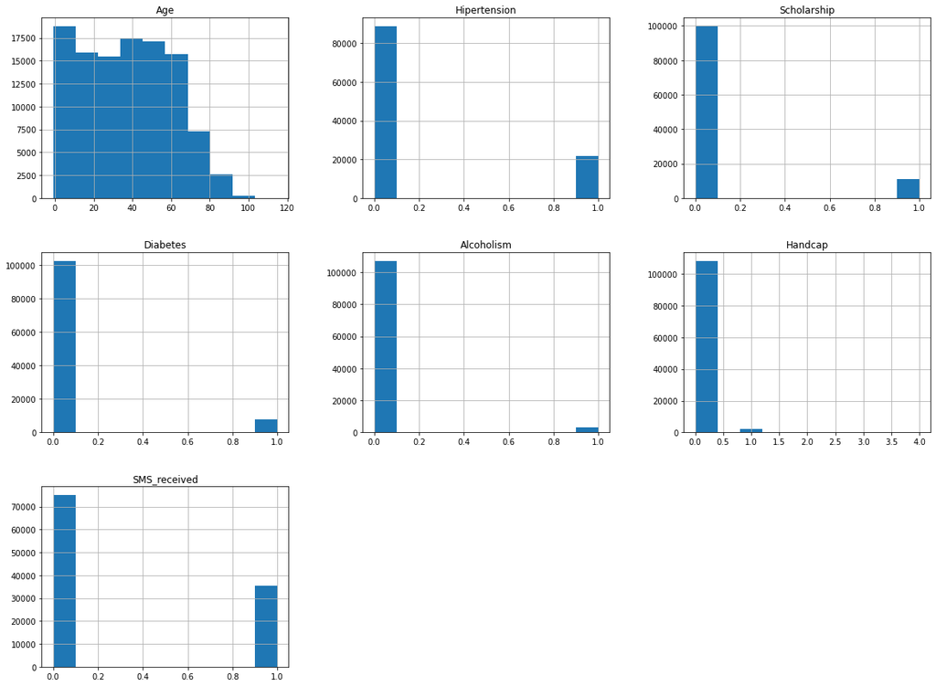

```python
column = ['Age', 'Hipertension', 'Scholarship', 'Diabetes', 'Alcoholism', 'Handcap', 'SMS_received']
df.hist(column=column, figsize=(20,15));
```

**Histogram observations**

**Gender**

```python
# Print unique values.
print("Unique values in 'Gender': {}".format(df['Gender'].unique()))
```

```
Unique values in 'Gender': ['F' 'M']
```

Where M and F signify Male and Female patients respectively.

**Age**

```python
# Print unique values.
print("Unique values in `Age': {}".format(df['Age'].unique()))
```

```
Unique values in `Age': [ 62  56   8  76  23  39  21  19  30  29  22  28  54  15  50  40  46   4
  13  65  45  51  32  12  61  38  79  18  63  64  85  59  55  71  49  78
  31  58  27   6   2  11   7   0   3   1  69  68  60  67  36  10  35  20
  26  34  33  16  42   5  47  17  41  44  37  24  66  77  81  70  53  75
  73  52  74  43  89  57  14   9  48  83  72  25  80  87  88  84  82  90
  94  86  91  98  92  96  93  95  97 102 115 100  99  -1]
```

Age value cannot be less than 0. All records of such values will be removed. There is also concerns with age values greater than 100 although they happen sometimes (see: https://en.wikipedia.org/wiki/Oldest_people). I will remove all age records greater than 100 as they are unlikely in such small dataset.

```python
# Check for age records less than 0 and age records greater than 100.
print('Before change:')
print("Patients with 'Age' less than -1: {}".format(df[df['Age'] <= -1].shape[0]))
print("Patients with 'Age' equal to 0: {}".format(df[df['Age'] == 0].shape[0]))
print("Patients with 'Age'  greater 100: {}".format(df[df['Age'] > 100].shape[0]))

# Create the dataframe range from Age 0 - 100.
df = df[(df['Age'] >= 0) & (df['Age'] <= 100)]
df['Age'].value_counts()

# Check for applied changes.
print('After change:')
print("Patients with 'Age' less than -1: {}".format(df[df['Age'] <= -1].shape[0]))
print("Patients with 'Age' equal to 0: {}".format(df[df['Age'] == 0].shape[0]))
print("Patients with 'Age'  greater 100: {}".format(df[df['Age'] > 100].shape[0]))
```

```
Before change:
Patients with 'Age' less than -1: 1
Patients with 'Age' equal to 0: 3539
Patients with 'Age'  greater 100: 7
After change:
Patients with 'Age' less than -1: 0
Patients with 'Age' equal to 0: 3539
Patients with 'Age'  greater 100: 0
```

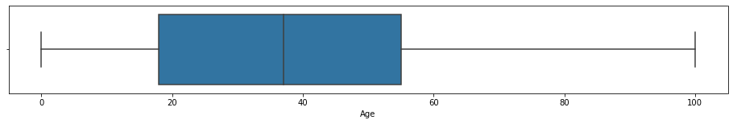

```python
# Let's see a boxplot showing Age values distribution (already seen in histogram and basic descriptive statistics table)
plt.figure(figsize=(16, 2))
sns.boxplot(x=df['Age']);
```

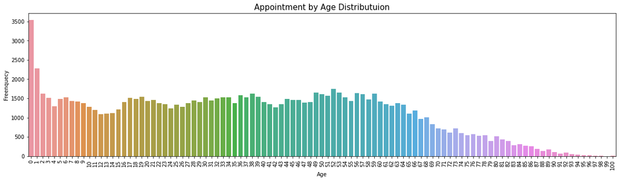

```python
# Let's see the number of appointment by age.
plt.figure(figsize=(20, 5))
plt.xticks(rotation=90)
ax = sns.countplot(x=df['Age'])
ax.set_title('Appointment by Age Distributuion', fontsize=15)
ax.set_xlabel('Age', fontsize=10)
ax.set_ylabel('Freenquecy', fontsize=10);
```

The above shows a peak for the infants (patients of age 0). For the young patients age values the distribution start to be uniform. After the age value of 60 the frequency starts to drop.

**Scholarship**

```python
# Print unique values
print("Unique values in 'Scholarship': {}".format(df['Scholarship'].unique()))
```

```
Unique values in 'Scholarship': [0 1]
```

**Hipertension**

```python
# Print unique values
print("Unique values in 'Hipertension': {}".format(df['Hipertension'].unique()))
```

```
Unique values in 'Hipertension': [1 0]
```

**Diabetes**

```python
# Print unique values
print("Unique values in 'Diabetes': {}".format(df['Diabetes'].unique()))
```

```
Unique values in 'Diabetes': [0 1]
```

**Alcoholism**

```python
# Print unique values
print("Unique values in 'Alcoholism': {}".format(df['Alcoholism'].unique()))
```

```
Unique values in 'Alcoholism': [0 1]
```

**Handcap**

```python
# Print unique values
print("Unique values in 'Handcap': {}".format(df['Handcap'].unique()))
```

```
Unique values in 'Handcap': [0 1 2 3 4]
```

```python
# Let's see the count of unique values in the Handcap column.
df['Handcap'].value_counts()
```

```
0    108282
1      2038
2       183
3        13
4         3
Name: Handcap, dtype: int64
```

There are many values in other classes other than class 0 and 1. These values make them potentially valid and not typos, so class 2,3,4 seems to be valid classes for different kinds of handicapness.

**SMS_received**

```python
# Print unique values
print("Unique values in 'SMS_received': {}".format(df['SMS_received'].unique()))
```

```
Unique values in 'SMS_received': [0 1]
```

**ScheduledDay**

```python
# Let's see the day the schedule of an appointment commenced and ended.
print('Scheduling an appointment started on: {}'.format(df['ScheduledDay'].min()))
print('Scheduling an appointment started on: {}'.format(df['ScheduledDay'].max()))
```

```
Scheduling an appointment started on: 2015-11-10 07:13:56+00:00
Scheduling an appointment started on: 2016-06-08 20:07:23+00:00
```

The appointment scheduling started on November, 10th 2015 as at 07:13 AM. The appointment scheduling ended on June, 8th 2016 as at 08:07 PM.

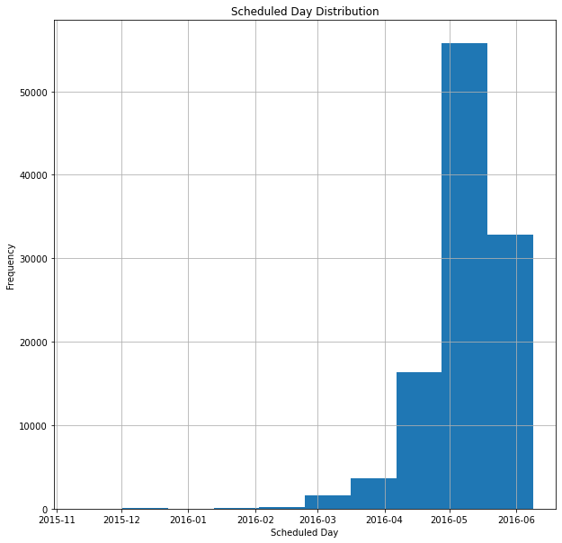

```python
# Frequency of the scheduledDay.
fig = plt.figure(figsize=(10, 10))
ax = fig.add_subplot(1, 1, 1)
df['ScheduledDay'].hist()
plt.title('Scheduled Day Distribution')
plt.xlabel('Scheduled Day')
plt.ylabel('Frequency');
```

The scheduled day distribution is left skewed. Most of the schedules were made between April and June of 2016.

**AppointmentDay**

```python
# Let's see the day the schedule of an appointment commenced and ended.
print('Visit appointment started on: {}'.format(df['AppointmentDay'].min()))
print('Visit appointment started on: {}'.format(df['AppointmentDay'].max()))
```

```
Visit appointment started on: 2016-04-29 00:00:00+00:00
Visit appointment started on: 2016-06-08 00:00:00+00:00
```

The visit appointment started on April, 29th 2016. The visit appointment ended on June, 8th 2016.

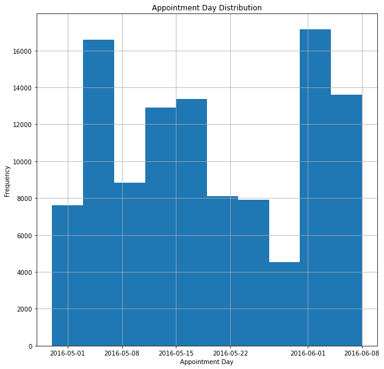

```python
# Frequency of the AppointmentDay.
fig = plt.figure(figsize=(10, 10))
ax = fig.add_subplot(1, 1, 1)
df['AppointmentDay'].hist()
plt.title('Appointment Day Distribution')
plt.xlabel('Appointment Day')
plt.ylabel('Frequency');
```

**AppointmentDOW**

```python
# Print unique values.
print("Unique values in 'AppointmentDOW': {}".format(df['AppointmentDOW'].unique()))
```

```
Unique values in 'AppointmentDOW': ['Fri' 'Tue' 'Mon' 'Wed' 'Thu' 'Sat']
```

```python
# Let's have another view on the data.
df.head()
```

|  | PatientId | AppointmentID | Gender | ScheduledDay | AppointmentDay | Age | Neighbourhood | Scholarship | Hipertension | Diabetes | Alcoholism | Handcap | SMS_received | Show | AppointmentDOW | AppointmentMonth |
| --- | --- | --- | --- | --- | --- | --- | --- | --- | --- | --- | --- | --- | --- | --- | --- | --- |
| 0 | 29872499824296 | 5642903 | F | 2016-04-29 18:38:08+00:00 | 2016-04-29 00:00:00+00:00 | 62 | JARDIM DA PENHA | 0 | 1 | 0 | 0 | 0 | 0 | Yes | Fri | Apr |
| 1 | 558997776694438 | 5642503 | M | 2016-04-29 16:08:27+00:00 | 2016-04-29 00:00:00+00:00 | 56 | JARDIM DA PENHA | 0 | 0 | 0 | 0 | 0 | 0 | Yes | Fri | Apr |
| 2 | 4262962299951 | 5642549 | F | 2016-04-29 16:19:04+00:00 | 2016-04-29 00:00:00+00:00 | 62 | MATA DA PRAIA | 0 | 0 | 0 | 0 | 0 | 0 | Yes | Fri | Apr |
| 3 | 867951213174 | 5642828 | F | 2016-04-29 17:29:31+00:00 | 2016-04-29 00:00:00+00:00 | 8 | PONTAL DE CAMBURI | 0 | 0 | 0 | 0 | 0 | 0 | Yes | Fri | Apr |
| 4 | 8841186448183 | 5642494 | F | 2016-04-29 16:07:23+00:00 | 2016-04-29 00:00:00+00:00 | 56 | JARDIM DA PENHA | 0 | 1 | 1 | 0 | 0 | 0 | Yes | Fri | Apr |

### **Questions**

Based on dataset analysis. I will focus on putting more light on answers to the following questions:

1. How many percent of patients missed their scheduled appointment?
2. What is the gender distribution for Show/No-show?
3. Are there patients with more than one appointment? If yes, what are the top 20 patients with most appointments?

## Exploratory Data Analysis

### 1. How many percent of patients missed their scheduled appointment?

```
20% of appointments were missed.
```

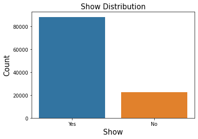

```python
all_appointments = len(df)
missed_appointments = df[(df['Show'] == 'No')].shape[0]
missed_ratio = int(round(missed_appointments / all_appointments*100))

# count plot of patients who show up.
feat = 'Show'

sns.countplot(x=feat, data=df)
plt.title('Show Distribution', fontsize=15)
plt.xlabel('Show', fontsize=15)
plt.ylabel('Count', fontsize=15)
plt.plot();

print('{}% of appointments were missed.'.format(missed_ratio))
```

### 2. What is the gender distribution for Show/No-show?

```
Out of 71832 appointments made by female patients, 14591 were missed with the ratio of 20%.
Out of 38687 appointments made by male patients, 7725 were missed with the ratio of 20%.
```

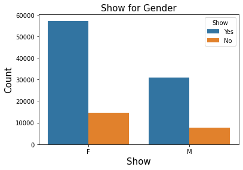

```python
appointments_by_f = len(df.loc[df['Gender'] == 'F'])
appointments_by_m = len(df.loc[df['Gender'] == 'M'])

missed_appointment_by_f = len(df.query("Gender == 'F' & Show == 'No'"))
missed_appointment_by_m = len(df.loc[(df['Gender'] == 'M') & (df['Show'] == 'No')])

missed_ratio_f = int(round(missed_appointment_by_f / appointments_by_f*100))
missed_ratio_m = int(round(missed_appointment_by_m / appointments_by_m*100))

# plot the show column.
feat = 'Gender'
hue = 'Show'

sns.countplot(x=feat, hue=hue, data=df)
plt.title('Show for Gender', fontsize=15)
plt.xlabel('Show', fontsize=15)
plt.ylabel('Count', fontsize=15)
plt.plot();

print('Out of {} appointments made by female patients, {} were missed with the ratio of {}%.'.format(appointments_by_f, missed_appointment_by_f, missed_ratio_f))
print('Out of {} appointments made by male patients, {} were missed with the ratio of {}%.'.format(appointments_by_m, missed_appointment_by_m, missed_ratio_m))
```

### 3. Are there patients with more than one appointment? If yes, what are the top 20 patients with most appointments?

```python
# change the display format to display the patientid
# in full instead of in exponential (8.221459e+14).
pd.options.display.float_format = '{:.0f}'.format

df.PatientId.value_counts().iloc[0:20]
```

```
822145925426128    88
99637671331        84
26886125921145     70
33534783483176     65
6264198675331      62
258424392677       62
75797461494159     62
871374938638855    62
66844879846766     57
872278549442       55
89239687393655     54
8435223536         51
853439686798559    50
65433599726992     46
14479974122994     46
81894521843749     42
9452745294842      42
188232341789524    40
2271579924275      38
9496196639835      38
Name: PatientId, dtype: int64
```

These are the multiple appointments. The number of appointments of top 20 range from 88 to 38.

## Conclusions

I have looked into the dataset and managed a few problems like removing wrong data, adding new features based on existing data. I have also investigated most of the independent variables in the dataset and made a few observations comparing them to each other as well as to the independent variables (Show). As this was only an exploratory analysis, many potential correlations may remain uncovered.